# 02_GEMSx003.0w1_Hands-On_Material

# Introduction to Spatial Data Analysis in R

## Instructors:

Ali Joglekar, University of Minnesota (joglekar@umn.edu)  
Yuan Chai, University of Minnesota (chaix026@umn.edu)

## Hands-On Material Outline

- I/O Point Data & Basic Maps
  - Exercise 1
- I/O Polygon Data & Basic Maps
  - Exercise 2
- I/O Raster Data & Basic Maps
  - Exercise 3
- Layering Features in Maps
  - Exercise 4

## Setup

### Load R Libraries

```r
packages_to_load <- c("sf", "terra", "tmap", "geodata")

for ( package in packages_to_load ) {
    # Check if package is already installed, if not, install and load the package
    if (!require(package, character.only=T, quietly=T, warn.conflicts=F)) {
        install.packages(package)
        suppressPackageStartupMessages(library(package, character.only=T, quietly=T, warn.conflicts=F))
    }
}
```

```
## terra 1.7.46
```

[output not shown]

[output not shown]

Note: For your own work, once packages are installed, it is recommended to just use `library()` to load your packages

```r
# Spatial data libraries
library(sf)
library(terra)
library(geodata)

# Plotting libraries
library(tmap)
```

### Data

In this example, we will use three data sets from the Minnesota Geospatial Commons, which have been downloaded, cleaned, transformed and saved in the directory `../data/MN` for this workshop.

1. Minnesota Six-Inch Soil Temperature: https://gisdata.mn.gov/dataset/geos-soil-temp-network
2. Groundwater Provinces of Minnesota 2021: https://gisdata.mn.gov/dataset/geos-groundwater-provinces-mn
3. Cropland Data Layer 2020, Minnesota: https://gisdata.mn.gov/dataset/agri-cropland-data-layer-2020

## **Working with Spatial Points Data in R**

### Importing XY data

Our first step is to read in the .csv file that contains our attribute data and geocordinates. For this example, we will be using the *Minnesota Six-Inch Soil Temperature* data.

> The Minnesota Department of Agriculture (MDA) Six-Inch Soil Temperature Network provides real time soil temperatures at locations across Minnesota. The network was established to assist in following best management practices for fall nitrogen fertilizer application which refer to a soil temperature at a six-inch depth.

For today’s workshop, a random October 5, 2021 temperature has been added for illustrative purposes. We first read in the .csv data.

```r
soil_samp <- read.csv("../data/MN/soil_samp/soil_samp_2021-10-05.csv")
head(soil_samp)
```

```
##   source         x        y          name temp_20211005
## 1    MDA -94.19423 44.20017        Judson      41.79259
## 2    MDA -95.42888 44.76222 Granite Falls      49.42997
## 3    MDA -93.26841 43.51400  Gordonsville      37.78381
## 4    MDA -94.35897 44.87780    Hutchinson      60.24301
## 5    MDA -96.30680 44.00319     Pipestone      58.48928
## 6    MDA -96.43726 43.77682        Jasper      46.85971
```

### Converting to `sf` Object

After identifying the longitude (x) and latitude (y) coordinates, we convert the *xy* data to an `sf` object using `st_as_sf`.

```r
soil_samp <- st_as_sf(soil_samp, coords = c("x","y"))
```

We’re setting the coordinate reference system (crs) to WGS84. This is represented by the European Petroleum Survey Group (EPSG) Code: 4326

### Summarizing Point Data

```r
head(soil_samp) #print data (top 6 rows)
```

```
## Simple feature collection with 6 features and 3 fields
## Geometry type: POINT
## Dimension:     XY
## Bounding box:  xmin: -96.43726 ymin: 43.514 xmax: -93.2684 ymax: 44.8778
## CRS:           NA
##   source          name temp_20211005                   geometry
## 1    MDA        Judson      41.79259 POINT (-94.19423 44.20017)
## 2    MDA Granite Falls      49.42997 POINT (-95.42888 44.76222)
## 3    MDA  Gordonsville      37.78381   POINT (-93.26841 43.514)
## 4    MDA    Hutchinson      60.24301  POINT (-94.35897 44.8778)
## 5    MDA     Pipestone      58.48928  POINT (-96.3068 44.00319)
## 6    MDA        Jasper      46.85971 POINT (-96.43726 43.77682)
```

```r
st_bbox(soil_samp) #bounding box
```

```
##      xmin      ymin      xmax      ymax
## -97.15028  43.51400 -91.80022  48.88353
```

```r
st_crs(soil_samp) #coordinate reference system
```

```
## Coordinate Reference System: NA
```

```r
st_crs(soil_samp) = 4326 #set crs to wgs84
st_crs(soil_samp)
```

```
## Coordinate Reference System:
##   User input: EPSG:4326
##   wkt:
## GEOGCRS["WGS 84",
##     ENSEMBLE["World Geodetic System 1984 ensemble",
##         MEMBER["World Geodetic System 1984 (Transit)"],
##         MEMBER["World Geodetic System 1984 (G730)"],
##         MEMBER["World Geodetic System 1984 (G873)"],
##         MEMBER["World Geodetic System 1984 (G1150)"],
##         MEMBER["World Geodetic System 1984 (G1674)"],
##         MEMBER["World Geodetic System 1984 (G1762)"],
##         MEMBER["World Geodetic System 1984 (G2139)"],
##         ELLIPSOID["WGS 84",6378137,298.257223563,
##             LENGTHUNIT["metre",1]],
##         ENSEMBLEACCURACY[2.0]],
##     PRIMEM["Greenwich",0,
##         ANGLEUNIT["degree",0.0174532925199433]],
##     CS[ellipsoidal,2],
##         AXIS["geodetic latitude (Lat)",north,
##             ORDER[1],
##             ANGLEUNIT["degree",0.0174532925199433]],
##         AXIS["geodetic longitude (Lon)",east,
##             ORDER[2],
##             ANGLEUNIT["degree",0.0174532925199433]],
##     USAGE[
##         SCOPE["Horizontal component of 3D system."],
##         AREA["World."],
##         BBOX[-90,-180,90,180]],
##     ID["EPSG",4326]]
```

```r
summary(soil_samp) #summary statistics
```

```
##     source              name           temp_20211005            geometry
##  Length:65          Length:65          Min.   :35.18   POINT        :65
##  Class :character   Class :character   1st Qu.:42.90   epsg:4326    : 0
##  Mode  :character   Mode  :character   Median :49.43   +proj=long...: 0
##                                        Mean   :49.09
##                                        3rd Qu.:54.89
##                                        Max.   :62.64
```

### Simple Maps from Point Data

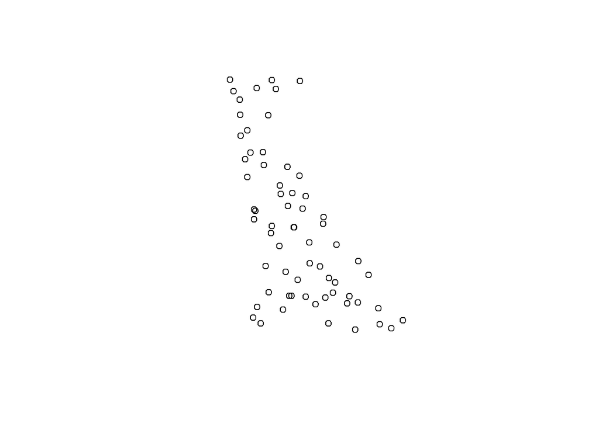

```r
plot(st_geometry(soil_samp))  #plots geometry
```

#### plotting with `base R`

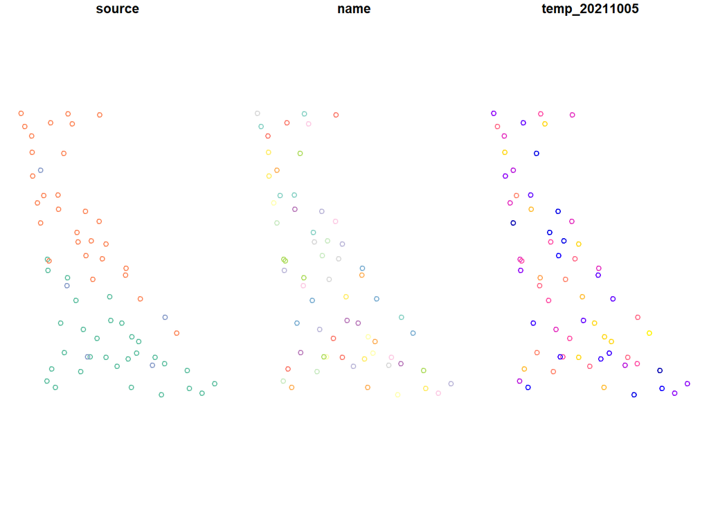

```r
#plots multiple variables
plot(soil_samp)
```

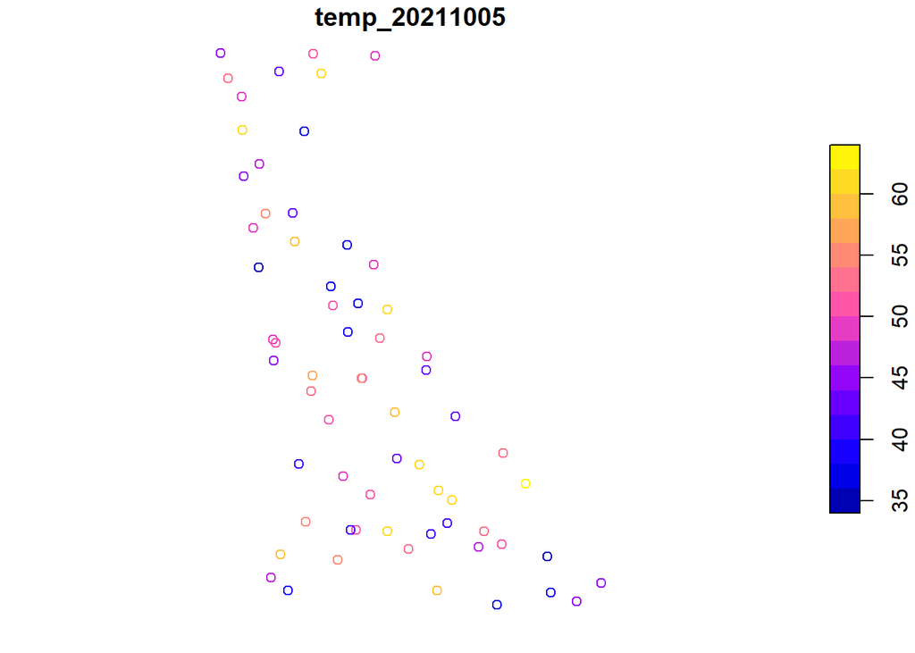

```r
#plots single variable
plot(soil_samp["temp_20211005"])
```

#### plotting with `tmap`

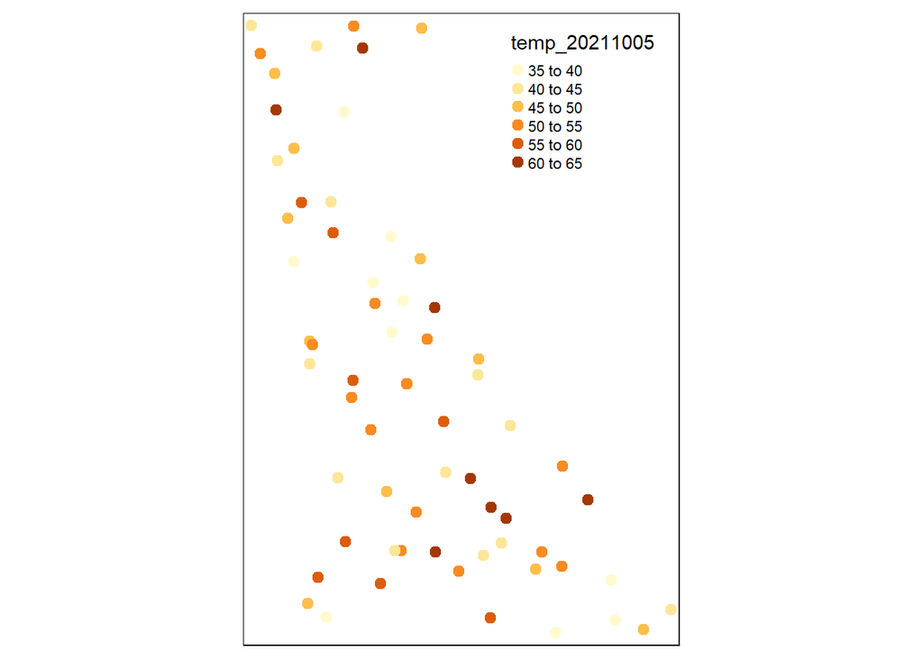

```r
tm_shape(soil_samp) +
  tm_dots("temp_20211005", size = 0.3)
```

### Export Points Data

`st_write(obj, "./path/.../filename.shp")`

### **Exercise 1: Explore Malawi LSMS Wave 5 (Point) Data**

> *Data Source:*  
> Malawi Living Standard Measurement Survey Integrated Household Sample (LSMS-IHS) Data Wave 5 Data is available from https://microdata.worldbank.org/index.php/catalog/3818

For today’s workshop, the data has been downloaded, cleaned, transformed, and saved in the directory `../data/MWI`.

1. Read-in the enumeration area geo-coordinates `ea_geo.csv` file.

```r
# Use this code block to work through the exercise
# Answers are available in separate .RMD file for Exercise 1
```

2. Identify the coordinate variables.
3. Convert data.frame object into an `sf` POINT object (assume a WGS84 CRS) and explore the data.

```r
# Use this code block to work through the exercise
# Answers are available in separate .RMD file for Exercise 1
```

4. Create some maps
   1. Plot a map of the geometry of the points in base R.
   2. Plot a map of all of variables in base R.
   3. Plot a map of the `dist_road` variable in base R.
   4. Plot a map of the `dist_road` variable in tmap.

```r
# Use this code block to work through the exercise
# Answers are available in separate .RMD file for Exercise 1
```

## **Working with Polygon Data in R**

### Importing Shapefiles

Our first step is to read in the .shp file that contains our attribute data and geometry data. For this example, we will be using the *Groundwater Provinces of Minnesota 2021* data.

> The Minnesota Groundwater Provinces map summarizes aquifer and groundwater resource differences at the regional level. Some parts of the state have several groundwater resources to choose from, while other parts of the state may have only limited groundwater resources available.

For today’s workshop, 3 random variables have been added as fields for illustrative purposes. We read in vector data using the `sf` package.

```r
gw_prov <- st_read("../data/MN/gw_prov") #shapefiles called only using data source name (dsn)
```

### Summarizing Polygon Data

```r
head(gw_prov) #print data (top 6 rows)
```

```
## Simple feature collection with 6 features and 6 fields
## Geometry type: MULTIPOLYGON
## Dimension:     XY
## Bounding box:  xmin: 300595.3 ymin: 4816307 xmax: 644098.4 ymax: 5169750
## Projected CRS: NAD83 / UTM zone 15N
##   PROVINCE Shape_Leng  Shape_Area var1 var2      var3
## 1        1 1960325.36 12926751300    a    g 251.35844
## 2        2 1215289.64 19748225306    b    d  86.55122
## 3        3   70080.53    77074828    b    g 214.59218
## 4        3   60446.17    57411939    b    g 214.59218
## 5        3   42736.64    31971013    b    g 214.59218
## 6        3  250596.20  1049117021    b    g 214.59218
##                         geometry
## 1 MULTIPOLYGON (((561759.8 51...
## 2 MULTIPOLYGON (((416918.9 49...
## 3 MULTIPOLYGON (((478174 4959...
## 4 MULTIPOLYGON (((421697.1 48...
## 5 MULTIPOLYGON (((482090.6 48...
## 6 MULTIPOLYGON (((554327.6 51...
```

```r
st_bbox(gw_prov) #bounding box
```

```
##      xmin      ymin      xmax      ymax
##  189775.3 4816306.6  761655.1 5472236.0
```

```r
st_crs(gw_prov) #coordinate reference system
```

```
## Coordinate Reference System:
##   User input: NAD83 / UTM zone 15N
##   wkt:
## PROJCRS["NAD83 / UTM zone 15N",
##     BASEGEOGCRS["NAD83",
##         DATUM["North American Datum 1983",
##             ELLIPSOID["GRS 1980",6378137,298.257222101,
##                 LENGTHUNIT["metre",1]]],
##         PRIMEM["Greenwich",0,
##             ANGLEUNIT["degree",0.0174532925199433]],
##         ID["EPSG",4269]],
##     CONVERSION["UTM zone 15N",
##         METHOD["Transverse Mercator",
##             ID["EPSG",9807]],
##         PARAMETER["Latitude of natural origin",0,
##             ANGLEUNIT["Degree",0.0174532925199433],
##             ID["EPSG",8801]],
##         PARAMETER["Longitude of natural origin",-93,
##             ANGLEUNIT["Degree",0.0174532925199433],
##             ID["EPSG",8802]],
##         PARAMETER["Scale factor at natural origin",0.9996,
##             SCALEUNIT["unity",1],
##             ID["EPSG",8805]],
##         PARAMETER["False easting",500000,
##             LENGTHUNIT["metre",1],
##             ID["EPSG",8806]],
##         PARAMETER["False northing",0,
##             LENGTHUNIT["metre",1],
##             ID["EPSG",8807]]],
##     CS[Cartesian,2],
##         AXIS["(E)",east,
##             ORDER[1],
##             LENGTHUNIT["metre",1]],
##         AXIS["(N)",north,
##             ORDER[2],
##             LENGTHUNIT["metre",1]],
##     ID["EPSG",26915]]
```

```r
summary(gw_prov) #summary statistics
```

```
##    PROVINCE           Shape_Leng        Shape_Area            var1
##  Length:42          Min.   :  18672   Min.   :1.170e+07   Length:42
##  Class :character   1st Qu.:  48939   1st Qu.:5.776e+07   Class :character
##  Mode  :character   Median :  90860   Median :1.728e+08   Mode  :character
##                     Mean   : 389743   Mean   :5.173e+09
##                     3rd Qu.: 216812   3rd Qu.:9.189e+08
##                     Max.   :2921536   Max.   :7.389e+10
##      var2                var3                 geometry
##  Length:42          Min.   : 86.55   MULTIPOLYGON :42
##  Class :character   1st Qu.:214.59   epsg:26915   : 0
##  Mode  :character   Median :240.79   +proj=utm ...: 0
##                     Mean   :238.41
##                     3rd Qu.:240.79
##                     Max.   :353.44
```

### Simple Choropleth Maps from Polygon Data

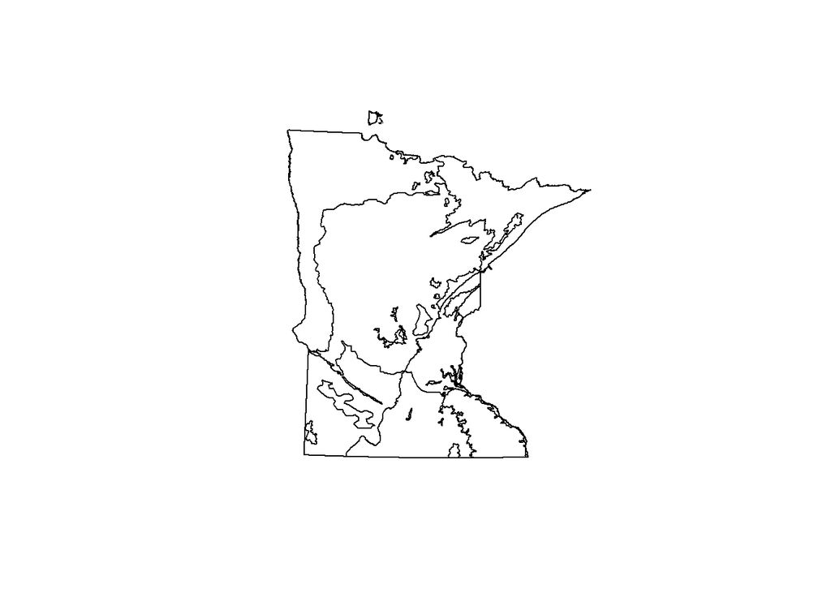

```r
plot(st_geometry(gw_prov))  #plots geometry
```

#### plotting with `base R`

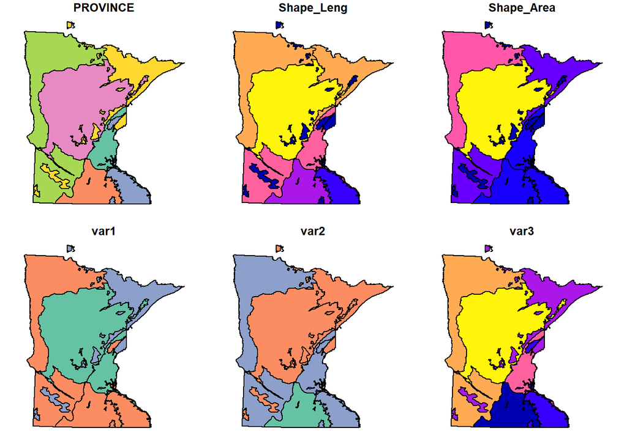

```r
#plots multiple variables
plot(gw_prov)
```

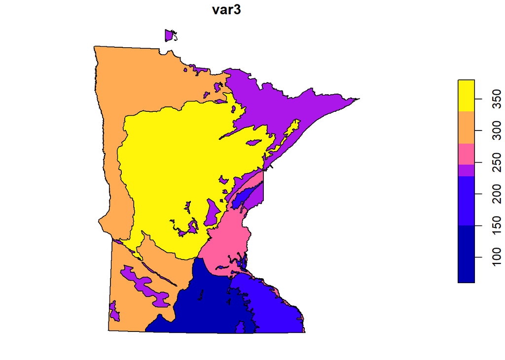

```r
#plots single variable
plot(gw_prov["var3"])
```